# 14주차

Hosub Park

2016년 6월 9일

## <14주차>

### 1.Using the Canadian occupational prestige data (the Prestige data frame in the car package see ?Prestige),

```
education
Average education of occupational incumbents, years, in 1971.

income
Average income of incumbents, dollars, in 1971.

women
Percentage of incumbents who are women.

prestige
Pineo-Porter prestige score for occupation, from a social survey conducted in the mid-1960s.

census
Canadian Census occupational code.

type
Type of occupation. A factor with levels (note: out of order): bc, Blue Collar; prof, Professional, Managerial, and Technical; wc, White Collar.
```

```r
library(faraway)
library(car)
data("Prestige")
summary(Prestige)
```

```
##    education          income          women           prestige
##  Min.   : 6.380   Min.   :  611   Min.   : 0.000   Min.   :14.80
##  1st Qu.: 8.445   1st Qu.: 4106   1st Qu.: 3.592   1st Qu.:35.23
##  Median :10.540   Median : 5930   Median :13.600   Median :43.60
##  Mean   :10.738   Mean   : 6798   Mean   :28.979   Mean   :46.83
##  3rd Qu.:12.648   3rd Qu.: 8187   3rd Qu.:52.203   3rd Qu.:59.27
##  Max.   :15.970   Max.   :25879   Max.   :97.510   Max.   :87.20
##      census       type
##  Min.   :1113   bc  :44
##  1st Qu.:3120   prof:31
##  Median :5135   wc  :23
##  Mean   :5402   NA's: 4
##  3rd Qu.:8312
##  Max.   :9517
```

#### (1) Fit a linear regression of prestige on education, income, type and women (i.e., percent women in the occupation) and explain the model.

```r
mdl <- lm(prestige~education+income+women+type, data=Prestige)
summary(mdl)
```

```
##
## Call:
## lm(formula = prestige ~ education + income + women + type, data = Prestige)
##
## Residuals:
##      Min       1Q   Median       3Q      Max
## -14.7485  -4.4817   0.3119   5.2478  18.4978
##
## Coefficients:
##               Estimate Std. Error t value Pr(>|t|)
## (Intercept) -0.8139032  5.3311558  -0.153 0.878994
## education    3.6623557  0.6458300   5.671 1.63e-07 ***
## income       0.0010428  0.0002623   3.976 0.000139 ***
## women        0.0064434  0.0303781   0.212 0.832494
## typeprof     5.9051970  3.9377001   1.500 0.137127
## typewc      -2.9170720  2.6653961  -1.094 0.276626
## ---
## Signif. codes:  0 '***' 0.001 '**' 0.01 '*' 0.05 '.' 0.1 ' ' 1
##
## Residual standard error: 7.132 on 92 degrees of freedom
##   (4 observations deleted due to missingness)
## Multiple R-squared:  0.8349, Adjusted R-squared:  0.826
## F-statistic: 93.07 on 5 and 92 DF,  p-value: < 2.2e-16
```

현재의 full model에서 재직자의 교육연수가 1년 증가할때마다 Pineo-Porter prestige score는 약 3.66점 증가하며, 재직자의 평균소득이 1 달러 증가할때마다 score는 0.001점증가한다. 나머지 predictor의 beta값은 0.05 수준에서 통계적으로 유의하지 않다. 그러나 모델자체의 F값은 유의하며 R-squared도 0.83으로 높다.

#### (2) Use “regression diagnostics” to check for problems in this regression and attempt to correct any problems that you discover.

**Outlier평가**

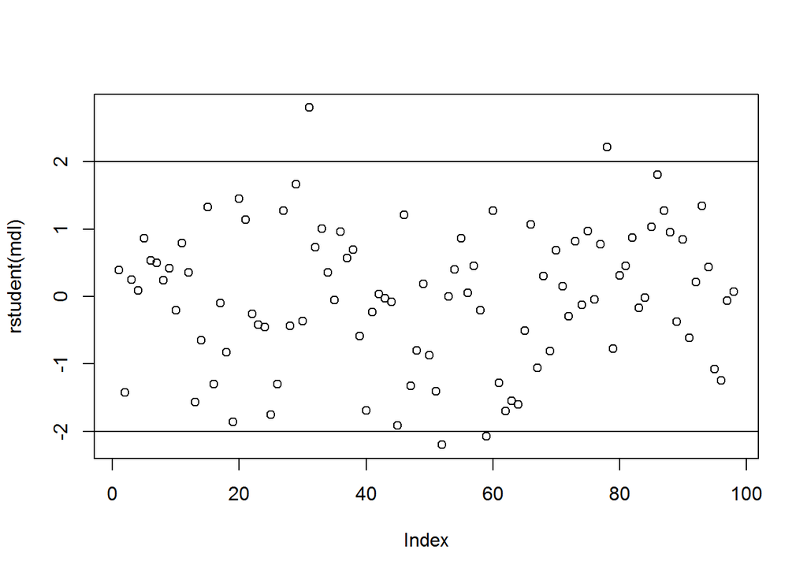

```r
plot(rstudent(mdl))
abline(h=c(-2,2))
```

```r
rstudent(mdl)[which(abs(rstudent(mdl))>2)]
```

```
##       medical.technicians service.station.attendant
##                  2.797377                 -2.198127
##                bartenders        electronic.workers
##                 -2.071109                  2.217450
```

```r
outlierTest(mdl)
```

```
##
## No Studentized residuals with Bonferonni p < 0.05
## Largest |rstudent|:
##                     rstudent unadjusted p-value Bonferonni p
## medical.technicians 2.797377           0.006287      0.61613
```

studentized residual의 절대값이 2 이상인 행이 4개 있지만 모두 Bonferonni p 값이 0.05이상으로 큰 outlier는 아니다.

**Leverage평가**

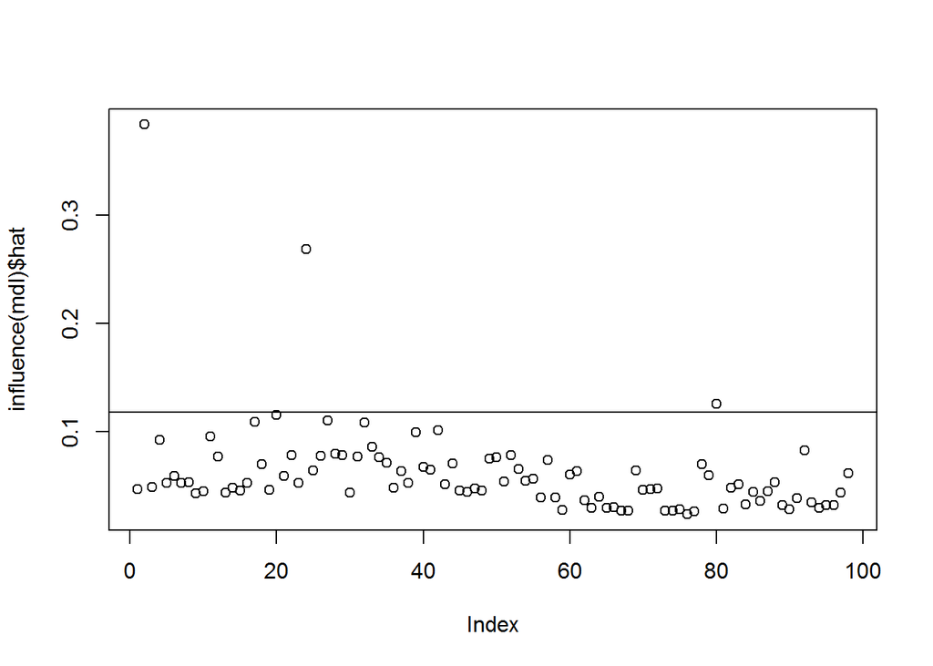

```r
plot(influence(mdl)$hat)
abline(h=2*6/102)
```

```r
influence(mdl)$hat[which(influence(mdl)$hat>2*6/102)]
```

```
##      general.managers            physicians sewing.mach.operators
##             0.3840315             0.2689646             0.1251906
```

Leverage가 큰 행이 3개 존재한다.

**Infuence 평가**

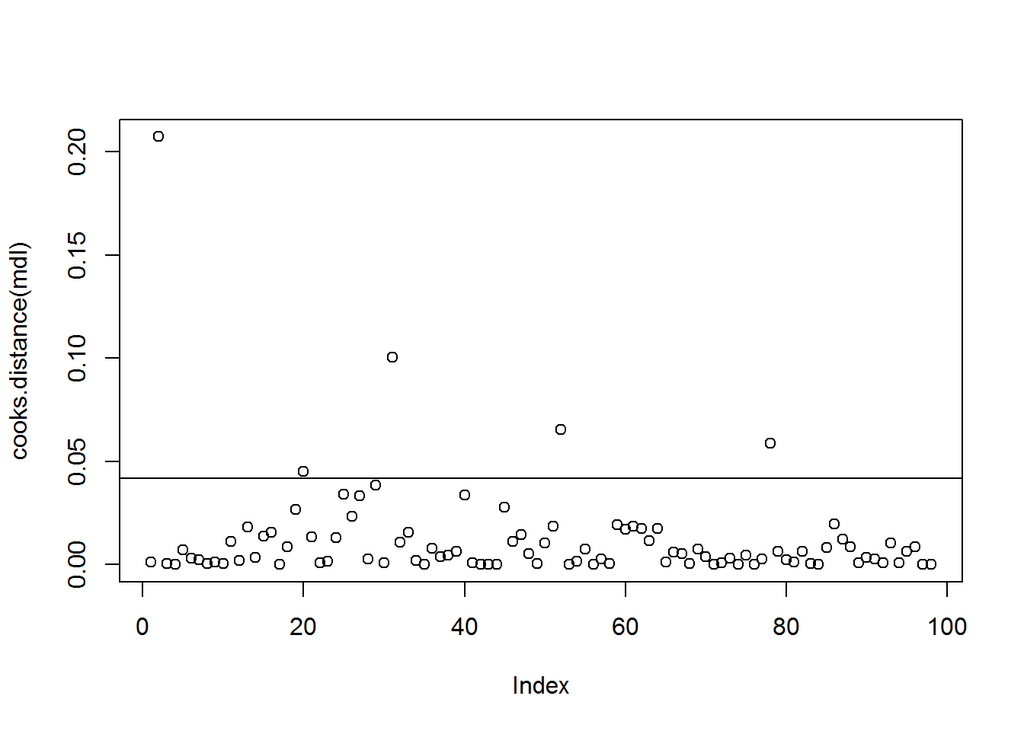

```r
plot(cooks.distance(mdl))
abline(h=4/(102-5-1))
```

```r
cooks.distance(mdl)[which(cooks.distance(mdl)>4/(102-5-1))]
```

```
##          general.managers                 ministers
##                0.20723271                0.04518542
##       medical.technicians service.station.attendant
##                0.10052381                0.06537028
##        electronic.workers
##                0.05859433
```

Leverage가 제일 큰 ’general.managers’가 가장 큰 influential point이다. 이외에도 큰 cook’s distance를 가진 행이 4개 더 있다.

**정규성평가**

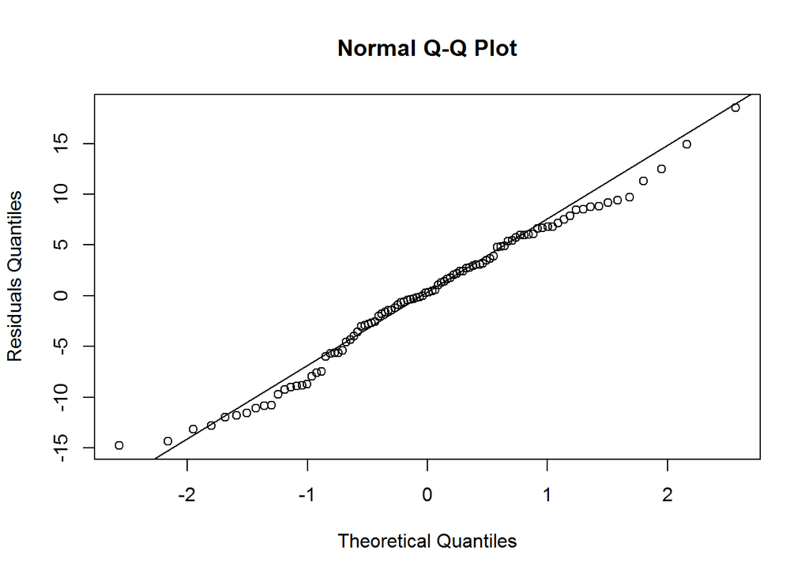

```r
qqnorm(mdl$residuals, ylab="Residuals Quantiles")
qqline(mdl$residuals)
```

```r
shapiro.test(mdl$residuals)
```

```
##
##  Shapiro-Wilk normality test
##
## data:  mdl$residuals
## W = 0.98519, p-value = 0.3415
```

shapiro test의 p 값이 0.34로 귀무가설을 기각할 수없으므로 residuals는 정규성을 띤다.

**등분산성 평가**

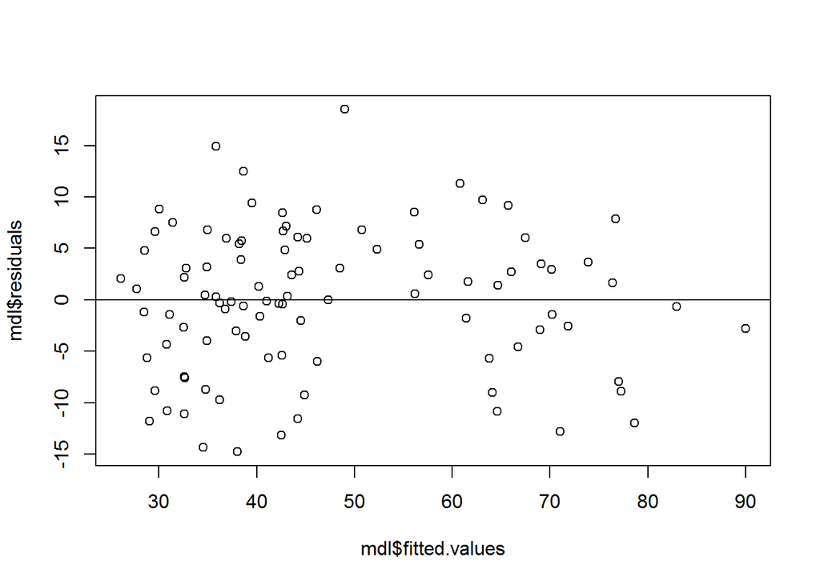

```r
plot(mdl$residuals~mdl$fitted.values)
abline(h=0)
```

```r
ncvTest(mdl)
```

```
## Non-constant Variance Score Test
## Variance formula: ~ fitted.values
## Chisquare = 0.06501254    Df = 1     p = 0.798742
```

Score test결과 p 값이 0.799로 귀무가설을 기각할 수 없으므로 residuals는 등분산성을 띤다.

**선형성 평가**

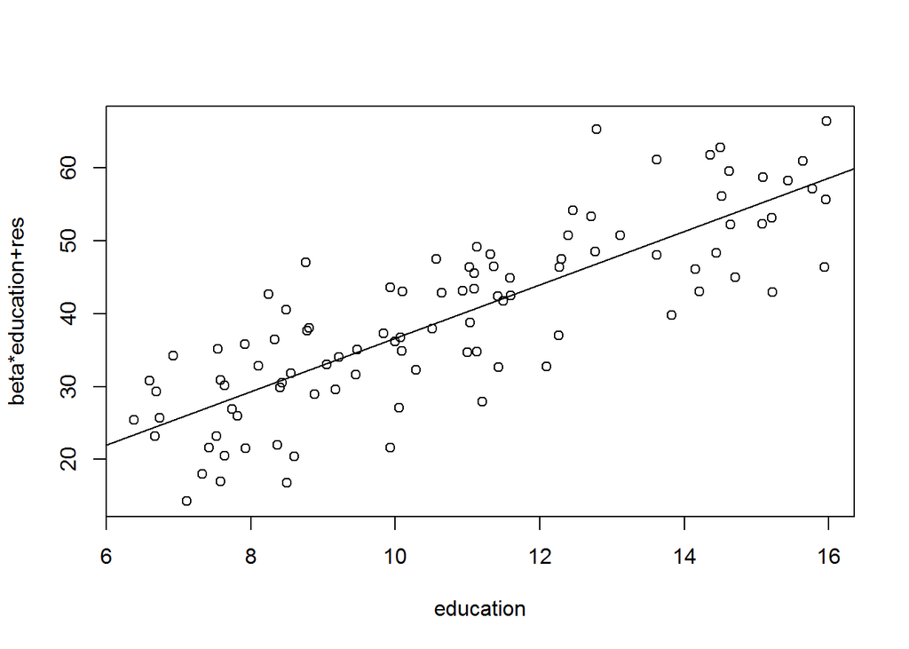

```r
prplot(mdl,1)
```

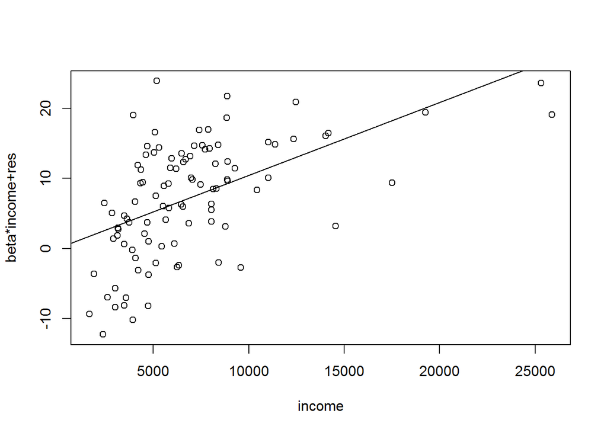

```r
prplot(mdl,2)
```

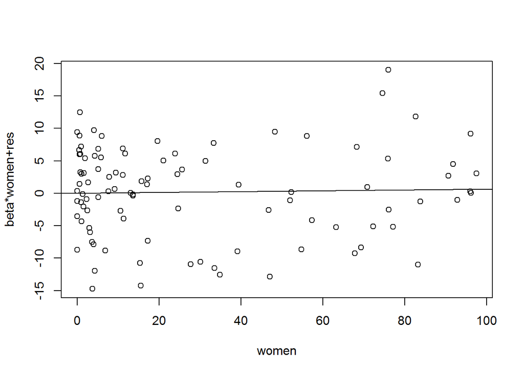

```r
prplot(mdl,3)
```

모든 continuous variable에서 모델은 선형성을 보인다.

**Collinearity 평가**

```r
vif(mdl)
```

```
##               GVIF Df GVIF^(1/(2*Df))
## education 6.011370  1        2.451810
## income    2.345613  1        1.531539
## women     1.733363  1        1.316573
## type      6.851642  2        1.617889
```

`education`과 `type`의 VIF가 5 이상으로 collinearity가 존재함.

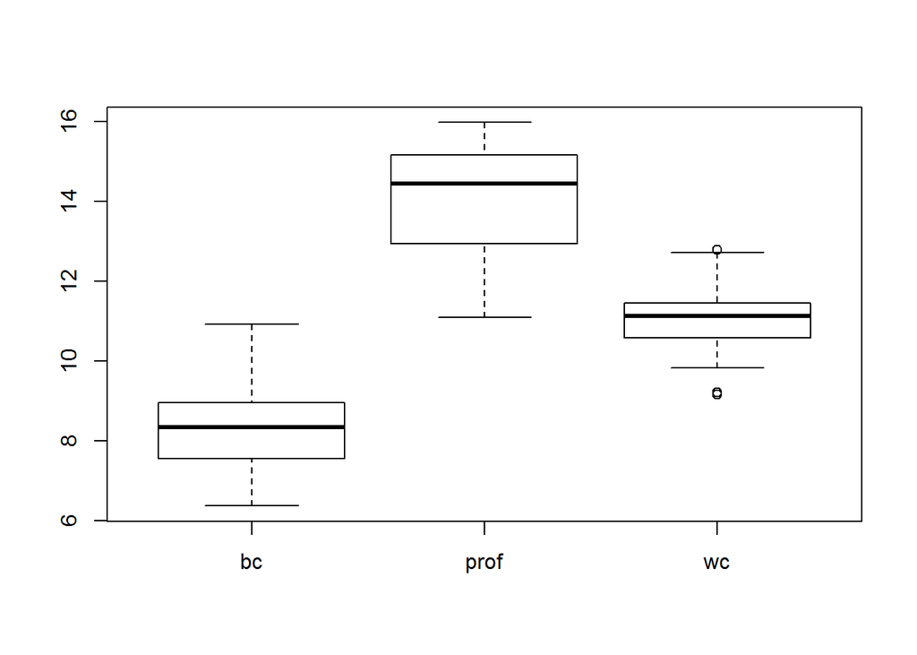

```r
boxplot(Prestige$education~Prestige$type)
```

Boxplot을 보면 `education`은 `type`에 따라 차이가 난다.

```r
max(Prestige$education[which(Prestige$type=="bc")])
```

```
## [1] 10.93
```

```r
min(Prestige$education[which(Prestige$type=="prof")])
```

```
## [1] 11.09
```

특히 `type`이 “bc”인 경우 `education의 최대값은 "prof"인 경우의 최소값보다 작다. 따라서`education`과`type`중 하나만을 사용하여 모델을 만든다.

**`education`만을 이용**

```r
mdl_e <- lm(prestige~education+income+women, data=Prestige)
summary(mdl_e)
```

```
##
## Call:
## lm(formula = prestige ~ education + income + women, data = Prestige)
##
## Residuals:
##      Min       1Q   Median       3Q      Max
## -19.8246  -5.3332  -0.1364   5.1587  17.5045
##
## Coefficients:
##               Estimate Std. Error t value Pr(>|t|)
## (Intercept) -6.7943342  3.2390886  -2.098   0.0385 *
## education    4.1866373  0.3887013  10.771  < 2e-16 ***
## income       0.0013136  0.0002778   4.729 7.58e-06 ***
## women       -0.0089052  0.0304071  -0.293   0.7702
## ---
## Signif. codes:  0 '***' 0.001 '**' 0.01 '*' 0.05 '.' 0.1 ' ' 1
##
## Residual standard error: 7.846 on 98 degrees of freedom
## Multiple R-squared:  0.7982, Adjusted R-squared:  0.792
## F-statistic: 129.2 on 3 and 98 DF,  p-value: < 2.2e-16
```

`women`을 제외한다.

```r
mdl_e2 <- update(mdl_e, ~.-women)
summary(mdl_e2)
```

```
##
## Call:
## lm(formula = prestige ~ education + income, data = Prestige)
##
## Residuals:
##      Min       1Q   Median       3Q      Max
## -19.4040  -5.3308   0.0154   4.9803  17.6889
##
## Coefficients:
##               Estimate Std. Error t value Pr(>|t|)
## (Intercept) -6.8477787  3.2189771  -2.127   0.0359 *
## education    4.1374444  0.3489120  11.858  < 2e-16 ***
## income       0.0013612  0.0002242   6.071 2.36e-08 ***
## ---
## Signif. codes:  0 '***' 0.001 '**' 0.01 '*' 0.05 '.' 0.1 ' ' 1
##
## Residual standard error: 7.81 on 99 degrees of freedom
## Multiple R-squared:  0.798,  Adjusted R-squared:  0.7939
## F-statistic: 195.6 on 2 and 99 DF,  p-value: < 2.2e-16
```

**`type`만을 이용**

```r
mdl_t <- lm(prestige~income+women+type, data=Prestige)
summary(mdl_t)
```

```
##
## Call:
## lm(formula = prestige ~ income + women + type, data = Prestige)
##
## Residuals:
##      Min       1Q   Median       3Q      Max
## -21.1395  -6.4714   0.0002   5.0597  24.6012
##
## Coefficients:
##              Estimate Std. Error t value Pr(>|t|)
## (Intercept) 2.714e+01  2.345e+00  11.573  < 2e-16 ***
## income      1.490e-03  2.891e-04   5.154 1.43e-06 ***
## women       2.004e-02  3.499e-02   0.573  0.56825
## typeprof    2.447e+01  2.530e+00   9.671 1.01e-15 ***
## typewc      6.517e+00  2.406e+00   2.709  0.00804 **
## ---
## Signif. codes:  0 '***' 0.001 '**' 0.01 '*' 0.05 '.' 0.1 ' ' 1
##
## Residual standard error: 8.24 on 93 degrees of freedom
##   (4 observations deleted due to missingness)
## Multiple R-squared:  0.7772, Adjusted R-squared:  0.7677
## F-statistic: 81.12 on 4 and 93 DF,  p-value: < 2.2e-16
```

`women`을 제외한다.

```r
mdl_t2 <- update(mdl_t, ~.-women)
summary(mdl_t2)
```

```
##
## Call:
## lm(formula = prestige ~ income + type, data = Prestige)
##
## Residuals:
##      Min       1Q   Median       3Q      Max
## -20.2141  -6.7359  -0.1931   5.1725  25.0776
##
## Coefficients:
##              Estimate Std. Error t value Pr(>|t|)
## (Intercept) 2.800e+01  1.801e+00  15.547  < 2e-16 ***
## income      1.401e-03  2.434e-04   5.757 1.07e-07 ***
## typeprof    2.506e+01  2.302e+00  10.884  < 2e-16 ***
## typewc      7.167e+00  2.114e+00   3.390  0.00102 **
## ---
## Signif. codes:  0 '***' 0.001 '**' 0.01 '*' 0.05 '.' 0.1 ' ' 1
##
## Residual standard error: 8.21 on 94 degrees of freedom
##   (4 observations deleted due to missingness)
## Multiple R-squared:  0.7765, Adjusted R-squared:  0.7693
## F-statistic: 108.8 on 3 and 94 DF,  p-value: < 2.2e-16
```

`education`만을 이용한 model이 adjusted R-squared 값이 더 크므로 최종모델로 선택한다.

```r
summary(mdl_e2)
```

```
##
## Call:
## lm(formula = prestige ~ education + income, data = Prestige)
##
## Residuals:
##      Min       1Q   Median       3Q      Max
## -19.4040  -5.3308   0.0154   4.9803  17.6889
##
## Coefficients:
##               Estimate Std. Error t value Pr(>|t|)
## (Intercept) -6.8477787  3.2189771  -2.127   0.0359 *
## education    4.1374444  0.3489120  11.858  < 2e-16 ***
## income       0.0013612  0.0002242   6.071 2.36e-08 ***
## ---
## Signif. codes:  0 '***' 0.001 '**' 0.01 '*' 0.05 '.' 0.1 ' ' 1
##
## Residual standard error: 7.81 on 99 degrees of freedom
## Multiple R-squared:  0.798,  Adjusted R-squared:  0.7939
## F-statistic: 195.6 on 2 and 99 DF,  p-value: < 2.2e-16
```